# How Twilio used Amazon SageMaker MLOps Pipelines with PrestoDB to enable frequent model re-training and optimized batch transform

*Amit Arora*, *Madhur Prashant*, *Antara Raisa*, *Johnny Chivers*

Today’s leading companies trust [Twilio’s](https://www.twilio.com/en-us) Customer Engagement Platform (CEP) to build direct, personalized relationships with their customers everywhere in the world. Twilio enables companies to use communications and data to add intelligence and security to every step of the customer journey, from sales to marketing to growth, customer service and many more engagement use cases in a flexible, programmatic way. Across 180 countries, millions of developers and hundreds of thousands of businesses use Twilio to create magical experiences for their customers. Being one of the largest AWS customers, Twilio engages with Data and AI/ML services to run their daily workloads. This blog outlines the steps AWS and Twilio took to migrate Twilio’s existing Machine Learning Operations (MLOps), the implementation of training models, and running batch inferences to Amazon SageMaker.

Machine learning (ML) models do not operate in isolation. They must integrate into existing production systems and infrastructure to deliver value. This necessitates considering the entire ML lifecycle during design and development. With the right processes and tools, MLOps enables organizations to reliably and efficiently adopt ML across their teams for their specific use cases. [Amazon SageMaker](https://aws.amazon.com/sagemaker/) includes a suite of features for MLOps that includes [Amazon SageMaker Pipelines](https://aws.amazon.com/sagemaker/pipelines/) and [Amazon SageMaker model registry](https://docs.aws.amazon.com/sagemaker/latest/dg/model-registry.html). Pipelines allow for straightforward creation and management of ML workflows while also offering storage and reuse capabilities for workflow steps. Model Registry simplifies model deployment by centralizing model tracking.

This blog post focuses on enabling AWS customers to have flexibility in using their data source of choice and integrate it seamlessly with [Amazon SageMaker Processing Jobs](https://sagemaker-examples.readthedocs.io/en/latest/sagemaker_processing/scikit_learn_data_processing_and_model_evaluation/scikit_learn_data_processing_and_model_evaluation.html). Using SageMaker Processing Jobs, you can leverage a simplified, managed experience to run data pre- or post-processing and model evaluation workloads on the Amazon SageMaker platform.

Twilio needed to implement an MLOps pipeline that queried data from [PrestoDB](https://prestodb.io/). PrestoDB is an open-source SQL query engine that is designed for fast analytic queries against data of any size from multiple sources.

In this post, we show you a step-by-step implementation to achieve the following:

- Read data available in PrestoDB from a SageMaker Processing Job
- Train a binary classification model using [SageMaker Training Jobs](https://sagemaker.readthedocs.io/en/v1.44.4/amazon_sagemaker_operators_for_kubernetes_jobs.html), and tune the model using [SageMaker Automatic Model Tuning](https://docs.aws.amazon.com/sagemaker/latest/dg/automatic-model-tuning.html)
- Run a [batch transform pipeline](https://docs.aws.amazon.com/sagemaker/latest/dg/batch-transform.html) for batch inference on data fetched from PrestoDB
- Deploy the trained model as a [real-time SageMaker endpoint](https://docs.aws.amazon.com/sagemaker/latest/dg/realtime-endpoints.html)

## Use case overview

Twilio trained a binary classification ML model using [scikit-learn’s](https://scikit-learn.org/stable/) [`RandomForestClassifier`](https://scikit-learn.org/stable/modules/generated/sklearn.ensemble.RandomForestClassifier.html) to integrate into their MLOps pipeline. This model is used as part of a batch process that runs periodically for their daily workloads, making training and inference workflows repeatable to accelerate model development. The training data used for this pipeline is made available via PrestoDB and read into Pandas through the [PrestoDB Python client](https://pypi.org/project/presto-python-client/).

The end goal was to convert the existing steps into two pipelines: a training pipeline and a batch transform pipeline that connected the data queried from PrestoDB to a SageMaker Processing Job, and finally deploy the trained model to a SageMaker Endpoint for real-time inference.

In this blog, we use an open-source dataset available via the [TPCH-Connector](https://prestodb.io/docs/current/connector/tpch.html) that is packaged with PrestoDB to illustrate the end-to-end workflow that Twilio used. Twilio was able to use this open-source solution to migrate their existing MLOps pipeline to Amazon SageMaker. All the code for this open-source solution is available in the [GitHub](https://github.com/aws-samples/mlops-pipeline-prestodb?tab=readme-ov-file) repo.

## Solution overview

This solution is divided into three main steps that implement a training pipeline, a batch transform pipeline, and deploy the trained model as a real-time SageMaker endpoint for inference:

- [Model Training Pipeline](https://github.com/aws-samples/mlops-pipeline-prestodb/blob/main/0_model_training_pipeline.ipynb): In this step, we create a model training pipeline. We connect a SageMaker Processing Job to fetch data from a PrestoDB instance, train and tune the ML model, evaluate it, and register it with the SageMaker Model Registry.
- [Batch Transform Pipeline](https://github.com/aws-samples/mlops-pipeline-prestodb/blob/main/1_batch_transform_pipeline.ipynb): In this step, we create a batch transform pipeline. Here, we execute a preprocess data step that reads data from a PrestoDB instance and runs batch inference on the registered ML model (from the Model Registry) that we [`approve`](https://docs.aws.amazon.com/sagemaker/latest/dg/model-registry-approve.html) as a part of this pipeline. This model is approved either programmatically or manually via the Model Registry.
- [Real-time Inference](https://github.com/aws-samples/mlops-pipeline-prestodb/blob/main/2_realtime_inference.ipynb): In this step, we deploy the latest approved model as a SageMaker Endpoint for [real-Time inference](https://docs.aws.amazon.com/sagemaker/latest/dg/realtime-endpoints.html).

## Solution design

The solution design includes setting up the data preparation and training pipeline, implementing the batch transform pipeline, and deploying the approved model as a real-time SageMaker endpoint for inference. All [pipeline parameters](https://docs.aws.amazon.com/sagemaker/latest/dg/build-and-manage-parameters.html) used in this solution exist in a single config.yml file. This file includes the necessary AWS and PrestoDB credentials to connect to the PrestoDB instance, information on the training hyperparameters and SQL queries that are executed at training, and inference steps to read data from PrestoDB. This solution is highly customizable for industry-specific use cases so that it can be used with minimal code changes via simple updates in the `config file`.

An example of how a query is configured within the `config.yml` file is shown below. This query is used at the [data processing step](https://docs.aws.amazon.com/sagemaker/latest/dg/build-and-manage-steps.html#step-type-processing) of the training pipeline to fetch data from the PrestoDB instance. Here, we predict whether an `order` is a `high_value_order` or a `low_value_order` based on the `orderpriority` as given from the `TPCH-data`. More information on the `TPCH-data`, its database entities, relationships, and characteristics can be found [here](https://www.tpc.org/tpc_documents_current_versions/pdf/tpc-h_v2.17.1.pdf). Users can change the query for their use case within the config file and execute the solution with no code changes.

```sql
    SELECT
        o.orderkey,
        COUNT(l.linenumber) AS lineitem_count,
        SUM(l.quantity) AS total_quantity,
        AVG(l.discount) AS avg_discount,
        SUM(l.extendedprice) AS total_extended_price,
        SUM(l.tax) AS total_payable_tax,
        o.orderdate,
        o.orderpriority,
        CASE
            WHEN (o.orderpriority = '2-HIGH') THEN 1
            ELSE 0
        END AS high_value_order
    FROM
        orders o
    JOIN
        lineitem l ON o.orderkey = l.orderkey
    GROUP BY
        o.orderkey,
        o.orderdate,
        o.orderpriority
    ORDER BY
        RANDOM()
    LIMIT 5000
```

The main steps of this solution are described in detail below:

### Part 1: [Data Preparation and Training Pipeline Step](https://github.com/aws-samples/mlops-pipeline-prestodb/blob/main/0_model_training_pipeline.ipynb):

1. The training data is read from a PrestoDB instance, and any feature engineering needed is done as part of the SQL queries run in PrestoDB at retrieval time. The queries that are used to fetch data at training and batch inference steps are configured in the `config file`.
2. We use the [FrameworkProcessor](https://docs.aws.amazon.com/sagemaker/latest/dg/processing-job-frameworks.html) with SageMaker Processing Jobs to read data from PrestoDB using the `Python PrestoDB client`.
3. For the training and tuning step, we use the [SKLearn estimator](https://sagemaker.readthedocs.io/en/stable/frameworks/sklearn/sagemaker.sklearn.html) from the SageMaker SDK and the `RandomForestClassifier` from `scikit-learn` to train the ML model. The [HyperparameterTuner](https://sagemaker.readthedocs.io/en/stable/api/training/tuner.html) class is used for running automatic model tuning that finds the best version of the model by running many training jobs on the dataset using the algorithm and the ranges of hyperparameters.
4. The [model evaluation](https://sagemaker-examples.readthedocs.io/en/latest/sagemaker-pipelines/tabular/abalone_build_train_deploy/sagemaker-pipelines-preprocess-train-evaluate-batch-transform.html) step is to check that the trained and tuned model has an accuracy level above a user-defined threshold and only then [register that model](https://docs.aws.amazon.com/sagemaker/latest/dg/model-registry.html) within the model registry. If the model accuracy does not meet the threshold, then the pipeline fails and the model is not registered with the model registry.
5. The model training pipeline is then run with the [`pipeline.start`](https://docs.aws.amazon.com/sagemaker/latest/dg/run-pipeline.html) which triggers and instantiates all the steps mentioned above.

### Part 2: [Batch Transform Step](https://github.com/aws-samples/mlops-pipeline-prestodb/blob/main/1_batch_transform_pipeline.ipynb):

1. The batch transform pipeline implements a data preparation step that retrieves data from a PrestoDB instance (using a [data preprocessing script](https://github.com/aws-samples/mlops-pipeline-prestodb/blob/main/code/presto_preprocess_for_batch_inference.py)) and stores the batch data in Amazon Simple Storage Service (S3).
2. The latest model registered in the Model Registry from the training pipeline is approved.
3. A [Transformer](https://sagemaker.readthedocs.io/en/stable/api/inference/transformer.html) instance is used which runs a batch transform job to get inferences on the entire dataset stored in S3 from the data preparation step and store the output in S3.

### Part 3: [Real-Time SageMaker Endpoint Support](https://github.com/aws-samples/mlops-pipeline-prestodb/blob/main/2_realtime_inference.ipynb):

1. The latest approved model is retrieved from the model registry using the [describe_model_package](https://boto3.amazonaws.com/v1/documentation/api/latest/reference/services/sagemaker/client/describe_model_package.html) function from the SageMaker SDK.
2. The latest approved model is deployed as a real-time SageMaker endpoint.
3. The model is deployed on a `ml.c5.xlarge` instance with a minimum instance count of 1 and a maximum instance count of 3 (configurable by the user) with the [automatic scaling policy](https://docs.aws.amazon.com/sagemaker/latest/dg/endpoint-auto-scaling.html) `ENABLED`. This removes unnecessary instances so that you don’t pay for provisioned instances that you aren’t using.

## Prerequisites

To implement the solution provided in this post, you should have an [AWS account](https://signin.aws.amazon.com/signin?redirect_uri=https%3A%2F%2Fportal.aws.amazon.com%2Fbilling%2Fsignup%2Fresume&client_id=signup), set up an [Amazon SageMaker Domain](https://docs.aws.amazon.com/sagemaker/latest/dg/sm-domain.html) to access [SageMaker Studio](https://aws.amazon.com/sagemaker/studio/), and have familiarity with SageMaker, S3, and PrestoDB.

The following prerequisites need to be in place before running this code:

#### PrestoDB

- We use the built-in datasets available in PrestoDB via the `TPCH-connector` for this solution. Follow the instructions in the GitHub [README.md](https://github.com/aws-samples/mlops-pipeline-prestodb?tab=readme-ov-file#prestodb) to set up PrestoDB on an Amazon EC2 instance in your account. *If you already have access to a PrestoDB instance, then you can skip this section but keep its connection details handy (see the `presto` section in the `config` file)*. Once you have your PrestoDB credentials, fill out the `presto` section in the `config` as given below. Enter your host `public IP`, `port`, `credentials`, `catalog` and `schema`:

```yaml
presto:
  host: <0.0.0.0>
  parameter: "0000"
  presto_credentials: <presto_credentials>
  catalog: <catalog>
  schema: <schema>
```

#### [Amazon VPC](https://aws.amazon.com/vpc/) Network Configurations

- We also define the encryption, network isolation, and VPC configurations of the ML model and operations in the `config` file. In the `aws` section, specify the `enable_network_isolation` status, `security_group_ids`, and `subnets` based on your network isolation preferences. View more information on network configurations and preferences [here](https://docs.aws.amazon.com/sagemaker/latest/dg/interface-vpc-endpoint.html). If you are using the default VPC and security groups then you can leave these configuration parameters empty, see example in this [configuration file](https://github.com/aws-samples/mlops-pipeline-prestodb/blob/main/config.yml).

```yaml
network_config:
    enable_network_isolation: false
    security_group_ids:
    - <security_group_id>
    subnets:
    - <subnet-1>
    - <subnet-2>
    - <subnet-3>
```

#### IAM Role

Set up an execution role in [AWS Identity and Access Management (IAM)](https://aws.amazon.com/iam/) with appropriate permissions to allow SageMaker to access [AWS Secrets Manager](https://docs.aws.amazon.com/secretsmanager/latest/userguide/intro.html) and S3. *Until an AWS CloudFormation template is provided that creates the role with the requisite IAM permissions, use a SageMaker execution role that AmazonSageMakerFullAccess AWS managed policy for your execution role.*

#### AWS Secrets Manager

Setup a secret in Secrets Manager for the PrestoDB username and password. Call the secret `prestodb-credentials` and add a `username` field to it and a `password` field to it. For instructions on creating and managing secrets via `Secrets Manager`, view [this link](https://docs.aws.amazon.com/secretsmanager/latest/userguide/managing-secrets.html).

### Steps to run

1. Clone the [GitHub repository](https://github.com/aws-samples/mlops-pipeline-prestodb.git) in SageMaker Studio. Follow this [link](https://docs.aws.amazon.com/sagemaker/latest/dg/studio-tasks-git.html) to view instructions on cloning a git repository in SageMaker Studio.
2. Edit the `config.yml` file as follows:
   - Edit the parameter values in the `presto` section. These parameters define the connectivity to PrestoDB.
   - Edit the parameter values in the `aws` section. These parameters define the network connectivity, IAM role, bucket name, region, and other AWS cloud-related parameters.
   - Edit the parameter values in the sections corresponding to the pipeline steps, i.e., `training_step`, `tuning_step`, `transform_step` etc.
   - Review all the parameters in these sections carefully, and edit them as appropriate for your use case.

## Testing the solution

### AWS Architecture

Once the prerequisites are complete and the `config.yml` file is set up correctly, we are ready to run the [`mlops-pipeline-prestodb`](https://github.com/aws-samples/mlops-pipeline-prestodb/tree/main) solution. View the architecture diagram for a visual representation of the steps that we implement. This diagram shows the following three steps: the training pipeline, the batch transform pipeline, and deploying the model as a SageMaker real-time endpoint:

[figure not shown]

Figure 1: mlops-pipeline-prestodb AWS Architecture Diagram

- **Solution Part 1**: Shows the architectural representation of the training pipeline. This includes the data preprocessing step, the training and tuning step, the model evaluation step, the condition step, and lastly, the register model step. The train, test, validation datasets, and [evaluation report](https://sagemaker-examples.readthedocs.io/en/latest/sagemaker-pipelines/tabular/abalone_build_train_deploy/sagemaker-pipelines-preprocess-train-evaluate-batch-transform.html) that are generated in this pipeline are sent to an S3 bucket.
- **Solution Part 2**: Shows the architectural representation of the batch transform pipeline. This includes the batch data preprocessing step, approving the latest model from the model registry, creating the model instance, and performing batch transformation on data that is stored and retrieved from an S3 bucket.
  - The PrestoDB server is hosted on an Amazon EC2 instance, with credentials stored in [AWS Secrets Manager](https://aws.amazon.com/secrets-manager/).
- **Solution Part 3**: Finally, the latest approved model from the SageMaker Model Registry is deployed as a SageMaker Real-Time Endpoint for inference.

### Solution Walkthrough

1. **Training Pipeline**: On the left panel in [SageMaker Studio](https://aws.amazon.com/sagemaker/studio/), choose **0_model_training_pipeline.inpynb** in the navigation pane. When the notebook is open, on the Run menu, choose **Run All Cells** to run the code in this notebook. This notebook demonstrates how SageMaker Pipelines can be used to string together a sequence of data processing, model training, tuning, and evaluation steps to train a binary classification ML model using scikit-learn. At the end of this run, navigate to `pipelines` on the Studio Navigation pane:

   **After executing the entire training pipeline, your pipeline structure on [Amazon SageMaker Pipelines](https://docs.aws.amazon.com/sagemaker/latest/dg/pipelines-sdk.html) should look like this:**

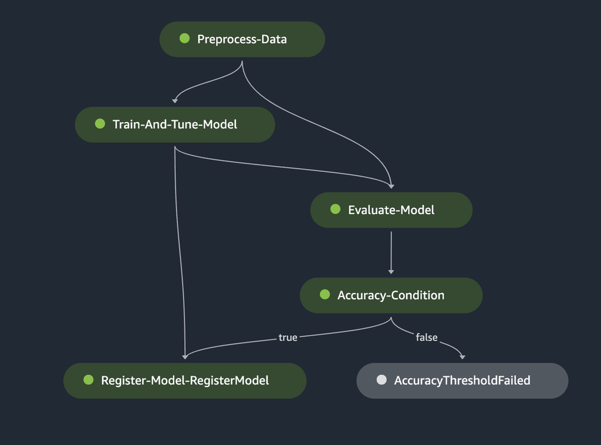

   Figure 2: Training Pipeline Structure

   *The training pipeline consists of the following steps that are implemented through the notebook run*:
   1. **Preprocess data step**: In this step of the pipeline, we create a processing job for data pre-processing. For more information on processing jobs, see [Process Data](https://docs.aws.amazon.com/sagemaker/latest/dg/processing-job.html). We use a [preprocess script](https://github.com/aws-samples/mlops-pipeline-prestodb/blob/main/code/presto_preprocess_for_training.py) that is used to connect and query data from a PrestoDB instance using the user-specified `SQL query` in the config file. This step splits and sends data retrieved from PrestoDB as `tain`, `test`, and `validation` files to an S3 bucket. The ML model is trained using the data in these files.

      The [sklearn_processor](https://docs.aws.amazon.com/sagemaker/latest/dg/use-scikit-learn-processing-container.html) is used in the [`ProcessingStep`](https://docs.aws.amazon.com/sagemaker/latest/dg/build-and-manage-steps.html#step-type-processing) to run the scikit-learn script that preprocesses data. The step is defined as follows:

      ```python
      # declare the sk_learn processer
      step_args = sklearn_processor.run(
              ## code refers to the data preprocessing script that is responsible for querying data from the PrestoDB instance
              code=config['scripts']['preprocess_data'],
              source_dir=config['scripts']['source_dir'],
              outputs=outputs_preprocessor,
              arguments=[
                  "--host", host_parameter,
                  "--port", port_parameter,
                  "--presto_credentials_key", presto_parameter,
                  "--region", region_parameter,
                  "--presto_catalog", presto_catalog_parameter,
                  "--presto_schema", presto_schema_parameter,
                  "--train_split", train_split.to_string(),
                  "--test_split", test_split.to_string(),
              ],
          )

          step_preprocess_data = ProcessingStep(
              name=config['data_processing_step']['step_name'],
              step_args=step_args,
          )
      ```

        ```python
        # declare a tuning step to use the train and test data to tune the ML model using the `HyperparameterTuner` declared above
        step_tuning = TuningStep(
            name=config['tuning_step']['step_name'],
            tuner=rf_tuner,
            inputs={
                "train": TrainingInput(
                    s3_data=step_preprocess_data.properties.ProcessingOutputConfig.Outputs[
                        "train" ## refer to this
                    ].S3Output.S3Uri,
                    content_type="text/csv",
                ),
                "test": TrainingInput(
                s3_data=step_preprocess_data.properties.ProcessingOutputConfig.Outputs["test"].S3Output.S3Uri,
                content_type="text/csv",
                ),
            },
        )
        ```

   3. **Evaluate model step**: This step in the pipeline checks if the trained and tuned model has an accuracy level above a user-defined threshold, and only then registers the model with the model registry. If the model accuracy does not meet the user-defined threshold then the pipeline fails and the model is not registered with the model registry. We use the [`ScriptProcessor`](https://docs.aws.amazon.com/sagemaker/latest/dg/processing-container-run-scripts.html) with an [evaluation script](https://github.com/aws-samples/mlops-pipeline-prestodb/blob/main/code/evaluate.py) that a user creates to evaluate the trained model based on a metric of choice.
      - The evaluation step uses the `evaluation script` as a code entry. This script prepares the features, target values and calculates the prediction probabilities using `model.predict`. At the end of the run, an `evaluation report` is sent to S3 that contains information on `precision, recall, accuracy` metrics.

      ```python
      step_evaluate_model = ProcessingStep(
          name=config['evaluation_step']['step_name'],
          processor=evaluate_model_processor,
          inputs=[
              ProcessingInput(
                  source=step_tuning.get_top_model_s3_uri(top_k=0, s3_bucket=bucket),
                  destination="/opt/ml/processing/model",
                  input_name="model.tar.gz"
              ),
              ProcessingInput(
                  source=step_preprocess_data.properties.ProcessingOutputConfig.Outputs["test"].S3Output.S3Uri,
                  destination="/opt/ml/processing/test",
                  input_name="test.csv"
              ),
          ],
          outputs=[
              ProcessingOutput(
                  output_name="evaluation",
                  source="/opt/ml/processing/evaluation",
                  destination=Join(
                      on="/",
                      values=[
                          "s3://{}".format(bucket),
                          prefix,
                          ExecutionVariables.PIPELINE_EXECUTION_ID,
                          "evaluation",
                      ]
                  )
              )
          ],
          code = config['scripts']['evaluation'],
          property_files=[evaluation_report],
          job_arguments=[
              "--target", target_parameter,
              "--features", feature_parameter,
          ]
      )
      ```

      - Once the evaluation step is complete, metrics like `Accuracy`, `Precision` and `Recall` can be analyzed from the `evaluation report` that is sent to the S3 bucket. View the image of an evaluation report sent below:

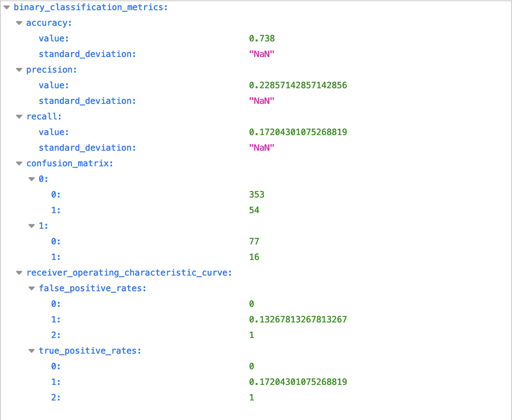

      Figure 3: Evaluation Report: Accuracy=73.8%, Precision=22.8%, Recall=17.2%

   4. **Condition model step**: Once the model is evaluated, we can add conditions to the pipeline with a [ConditionStep](https://sagemaker.readthedocs.io/en/stable/workflows/pipelines/sagemaker.workflow.pipelines.html). This step registers the model only if the given user-defined metric threshold is met. In our solution, we only want to register the new model version with the Model Registry if the new model meets a specific accuracy condition of above `70%`.

      ```python
      # Create a SageMaker Pipelines ConditionStep, using the condition above.
      # Enter the steps to perform if the condition returns True / False.
      step_cond = ConditionStep(
          name=config['condition_step']['step_name'],
          conditions=[cond_gte],
          if_steps=[step_register_model],
          else_steps=[step_fail], ## if this fails
      )
      ```

      If the `accuracy condition` is not met, a `step_fail` step is executed that sends an error message to the user, and the pipeline fails. For instance, since the user-defined `accuracy condition` is set to `0.7` in the `config file`, and the Accuracy calculated during the evaluation step exceeds it (`73.8% > 70%`), the `outcome` of this step is set to `True` and the model moves to the last step of the training pipeline.
   5. **Register model step**: This `RegisterModel` step is to register a [sagemaker.model.Model](https://sagemaker.readthedocs.io/en/stable/api/inference/model.html) or a [sagemaker.pipeline.PipelineModel](https://sagemaker.readthedocs.io/en/stable/api/inference/pipeline.html#pipelinemodel) with the Amazon SageMaker model registry. Once the trained model meets the model performance requirements, a new version of the model is registered with the `SageMaker Model Registry`.

      *The model is registered with the `model registry` with an approval status set to `PendingManualApproval`. This means the model cannot be deployed on a SageMaker endpoint unless its status in the registry is changed to `Approved` manually via the SageMaker console, programmatically or through an `AWS Lambda` function.*

      *Now that the model is registered, you can get access to the registered model manually on the SageMaker Studio Model Registry console or programmatically in the next notebook, approve it, and run the second portion of this solution: Batch Transform Step*
2. **Batch Transform Pipeline**: Next Choose [`1_batch_transform_pipeline.ipynb`](https://github.com/aws-samples/mlops-pipeline-prestodb/blob/main/1_batch_transform_pipeline.ipynb). When the notebook is open, on the Run menu, choose **Run All Cells** to run the code in this notebook. This notebook will run a batch transform pipeline using the model trained in the previous notebook.

   **At the end of the batch transform pipeline execution, your pipeline structure on Amazon SageMaker Pipelines should look like this:**

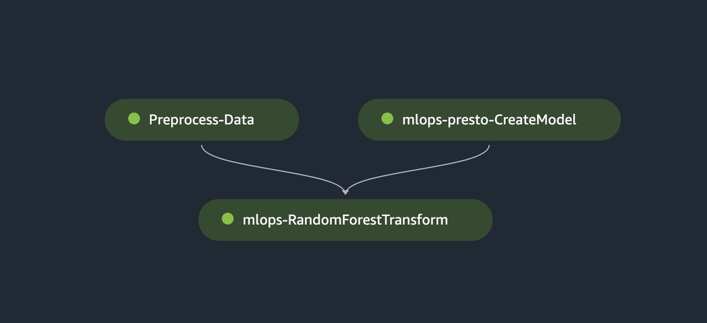

   Figure 4: Batch Transform Pipeline Structure

   *The batch transform pipeline consists of the following steps that are implemented through the notebook run:*
   1. **Extract the latest approved model from the SageMaker Model Registry**: In this step of the pipeline, we extract the latest model from the Model Registry and set the `ModelApprovalStatus` to `Approved`:

      ```python
      ## updating the latest model package to approved status to use it for batch inference
      model_package_update_response = sm.update_model_package(
          ModelPackageArn=latest_model_package_arn,
          ModelApprovalStatus="Approved",
      )
      ```

      Now we have extracted the latest model from the SageMaker Model Registry and programmatically approved it. You can also approve the model manually on the `SageMaker Model Registry` page in SageMaker Studio as shown in the image below.

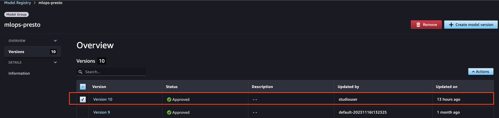

      Figure 5: SageMaker Model Registry: Manual Model Approval via SageMaker Studio

   2. **Read raw data for inference from PrestoDB and store it in an Amazon S3 bucket**: Once the latest model is approved, batch data is fetched from the PrestoDB instance and used for the batch transform step. In this step, we use a [batch preprocess script](https://github.com/aws-samples/mlops-pipeline-prestodb/blob/main/code/presto_preprocess_for_batch_inference.py) that queries data from PrestoDB and saves it in a batch directory within an S3 bucket. The query that is used to fetch batch data is configured by the user within the `config file` in the `transform_step` section.

      ```python
      # declare the batch step that is called later in pipeline execution
      batch_data_prep = ProcessingStep(
          name=config['data_processing_step']['step_name'],
          step_args=step_args,
      )
      ```

      Once the batch data is extracted into the S3 bucket, create a model instance and point to the [‘inference.py’](https://github.com/aws-samples/mlops-pipeline-prestodb/blob/main/code/inference.py) script, which contains code that runs as part of getting inference from the trained model.

      ```python
      # create the model image based on the model data and refer to the inference script as an entry point for batch inference
      model = Model(
          image_uri=image_uri,
          entry_point=config['scripts']['batch_inference'],
          model_data=model_data_url,
          sagemaker_session=pipeline_session,
          role=role,
      )
      ```

   3. **Create a batch transform step to perform inference on the batch data stored in S3**: Now that a model instance is created, create a [Transformer](https://sagemaker.readthedocs.io/en/stable/api/inference/transformer.html) instance with the appropriate model type, compute instance type, and desired output S3 URI. Specifically, pass in the `ModelName` from the [`CreateModelStep`](https://docs.aws.amazon.com/sagemaker/latest/APIReference/API_CreateModel.html), `step_create_model` properties. The `CreateModelStep` properties attribute matches the object model of the `DescribeModel` response object. Use a `transform step` for batch transformation to run inference on an entire dataset. For more information about batch transform, see [Run Batch Transforms with Inference Pipelines](https://docs.aws.amazon.com/sagemaker/latest/dg/inference-pipeline-batch.html).
      - A transform step requires a transformer and the data on which to run batch inference.

        ```python
        transformer = Transformer(
        model_name=step_create_model.properties.ModelName,
        instance_type=config['transform_step']['instance_type'],
        instance_count=config['transform_step']['instance_count'],
        strategy="MultiRecord",
        accept="text/csv",
        assemble_with="Line",
        output_path=f"s3://{bucket}",
        tags = config['transform_step']['tags'],
        env={
            'START_TIME_UTC': st.strftime('%Y-%m-%d %H:%M:%S'),
            'END_TIME_UTC': et.strftime('%Y-%m-%d %H:%M:%S'),
        })
        ```

      - Now that the transformer object is created, pass the transformer input (which contains the batch data from the `batch preprocess` step) into the `TransformStep` declaration. Store the output of this pipeline in an S3 bucket.

      ```python
      step_transform = TransformStep(
          name=config['transform_step']['step_name'], transformer=transformer, inputs=transform_input,
      )
      ```

3. **SageMaker Real-Time Inference**: Lastly, choose [`2_realtime_inference.ipynb`](https://github.com/aws-samples/mlops-pipeline-prestodb/blob/main/2_realtime_inference.ipynb). When the notebook is open, on the Run menu, choose **Run All Cells** to run the code in this notebook. This notebook extracts the latest approved model from the Model Registry and deploys it as a SageMaker endpoint for real-time inference. It does so by executing the following steps:
   1. **Extract the latest approved model from the SageMaker Model Registry**: To deploy a real-time SageMaker endpoint, first fetch the `image uri` of your choice and extract the latest approved model from the Model Registry. Once the latest approved model is extracted, we use a container list with the specified `inference.py` as the script for the deployed model to use at inference. This model creation and endpoint deployment are specific to the [scikit-learn model](https://sagemaker.readthedocs.io/en/stable/frameworks/sklearn/sagemaker.sklearn.html) configuration.

      In this code, we use the `inference.py` file specific to the scikit-learn model. We then create our endpoint configuration, setting our `ManagedInstanceScaling` to `ENABLED` with our desired `MaxInstanceCount` and `MinInstanceCount` for automatic scaling:

      ```python
      create_endpoint_config_response = sm.create_endpoint_config(
      EndpointConfigName = endpoint_config_name,
      ProductionVariants=[{
          'InstanceType': instance_type,
          # have max instance count configured here
          'InitialInstanceCount': min_instances,
          'InitialVariantWeight': 1,
          'ModelName': model_name,
          'VariantName': 'AllTraffic',
          # change your managed instance configuration here
          "ManagedInstanceScaling":{
              "MaxInstanceCount": max_instances,
              "MinInstanceCount": min_instances,
              "Status": "ENABLED",}
      }])
      ```

   2. **Run inferences on the deployed real time endpoint**: Once you have extracted the latest approved model, created the model from the desired `image uri`, and configured the `Endpoint configuration`, you can then deploy it as a real-time SageMaker endpoint.

      ```python
      create_endpoint_response = sm.create_endpoint(
      EndpointName=endpoint_name,
      EndpointConfigName=endpoint_config_name)

      # wait for endpoint to reach a terminal state (InService) using describe endpoint
      describe_endpoint_response = sm.describe_endpoint(EndpointName=endpoint_name)

      while describe_endpoint_response["EndpointStatus"] == "Creating":
          describe_endpoint_response = sm.describe_endpoint(EndpointName=endpoint_name)
      ```

      Upon deployment, you can view the endpoint in service on the SageMaker Endpoints under the Inference option on the left panel:

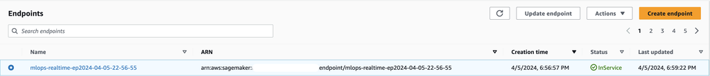

   3. **Now, run inference against the data extracted from PrestoDB**:

      ```python
      body_str = "total_extended_price,avg_discount,total_quantity\n1,2,3\n66.77,12,2"

      response = smr.invoke_endpoint(
          EndpointName=endpoint_name,
          Body=body_str.encode('utf-8') ,
          ContentType='text/csv',
      )

      response_str = response["Body"].read().decode()
      response_str
      ```

## Results

Here is an example of an inference request and response from the real time endpoint using the implementation above:

**Inference request format** (view and change this example as you would like for your custom use case)

```python
body_str = """total_extended_price,avg_discount,total_quantity
32,40,334
"""

response = smr.invoke_endpoint(
    EndpointName=endpoint_name,
    Body=body_str.encode('utf-8'),
    ContentType='text/csv',
)

response_str = response["Body"].read().decode()
data = json.loads(response_str)
print(json.dumps(data, indent=4))
```

**Response from the real time endpoint**

```json
[
    {
        "total_extended_price": 32,
        "avg_discount": 40,
        "total_quantity": 334,
        "prediction": 0
    }
]
```

## Clean Up Steps

If you decide to clean up the endpoint in service, navigate to the `endpoints` section under `inference` on the SageMaker console, select the endpoint to be deleted, click on `Actions` and delete the endpoint to avoid extra charges.

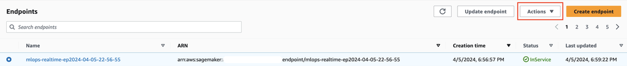

Figure 6: Delete the endpoint in service

## Conclusion

We have demonstrated an end-to-end MLOps solution on SageMaker. The process involved fetching data by connecting a SageMaker Processing Job to a PrestoDB instance, followed by training, evaluating, and registering the model. We approved the latest registered model from the training pipeline and ran batch inference against it using batch data queried from PrestoDB and stored in S3. Furthermore, we deployed the latest approved model as a real-time SageMaker endpoint to run inferences.

The rise of [generative AI](https://aws.amazon.com/generative-ai/) increases the demand for training, deploying, and running ML models, and consequently, the use of data. By integrating SageMaker Processing Jobs with PrestoDB, you can seamlessly migrate your workloads to SageMaker pipelines without additional data preparation, storage, or accessibility burdens. You can build, train, evaluate, run batch inferences, and deploy models as real-time endpoints while leveraging your existing data engineering pipelines with minimal or no code changes.

Explore SageMaker Pipelines, open-source data querying engines like PrestoDB, and build a solution using the sample implementation provided.

Get started today by refering to this [GitHub repository](https://github.com/aws-samples/mlops-pipeline-prestodb.git).

For more information and tutorials on SageMaker Pipelines, refer to the [SageMaker Pipelines Documentation](https://docs.aws.amazon.com/search/doc-search.html?searchPath=documentation&searchQuery=sagemaker+pipelines).

## Author bio

Amit Arora is an AI and ML Specialist Architect at Amazon Web Services, helping enterprise customers use cloud-based machine learning services to rapidly scale their innovations. He is also an adjunct lecturer in the MS data science and analytics program at Georgetown University in Washington D.C.

Madhur Prashant is an AI and ML Solutions Architect at Amazon Web Services. He is passionate about the intersection of human thinking and generative AI. His interests lie in generative AI, specifically building solutions that are helpful and harmless, and most of all optimal for customers. Outside of work, he loves doing yoga, hiking, spending time with his twin, and playing the guitar.

Antara Raisa is an AI and ML Solutions Architect at Amazon Web Services supporting Strategic Customers based out of Dallas, Texas. She also has previous experience working with large enterprise partners at AWS, where she worked as a Partner Success Solutions Architect for digital native customers.

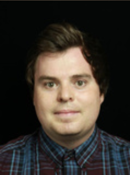

Johnny is a Senior Solutions Architect working within the Strategic Accounts team at AWS. With over 10 years of experience helping customers adopt new technologies, he guides them through architecting end-to-end solutions spanning infrastructure, big data, and AI.